# a01_classification_eda

**Kernel Author:**  
[Bhishan Poudel, Ph.D Astrophysics](https://bhishanpdl.github.io/) .

In this dataset, you are provided over a hundred variables describing attributes of life insurance applicants. The task is to predict the "Response" variable for each Id in the test set. "Response" is an ordinal measure of risk that has 8 levels.

## File descriptions

- **train.csv** - the training set, contains the Response values
- **test.csv** - the test set, you must predict the Response variable for all rows in this file
- **sample_submission.csv** - a sample submission file in the correct format

## Data fields

| **Variable** | **Description** |
| --- | --- |
| Id | A unique identifier associated with an application. |
| Product_Info_1-7 | A set of normalized variables relating to the product applied for |
| Ins_Age | Normalized age of applicant |
| Ht | Normalized height of applicant |
| Wt | Normalized weight of applicant |
| BMI | Normalized BMI of applicant |
| Employment_Info_1-6 | A set of normalized variables relating to the employment history of the applicant. |
| InsuredInfo_1-6 | A set of normalized variables providing information about the applicant. |
| Insurance_History_1-9 | A set of normalized variables relating to the insurance history of the applicant. |
| Family_Hist_1-5 | A set of normalized variables relating to the family history of the applicant. |
| Medical_History_1-41 | A set of normalized variables relating to the medical history of the applicant. |
| Medical_Keyword_1-48 | A set of dummy variables relating to the presence of/absence of a medical keyword being associated with the application. |
| Response | This is the target variable, an ordinal variable relating to the final decision associated with an application |

**The following variables are all categorical (nominal):**

Product_Info_1, Product_Info_2, Product_Info_3, Product_Info_5, Product_Info_6, Product_Info_7, Employment_Info_2, Employment_Info_3, Employment_Info_5, InsuredInfo_1, InsuredInfo_2, InsuredInfo_3, InsuredInfo_4, InsuredInfo_5, InsuredInfo_6, InsuredInfo_7, Insurance_History_1, Insurance_History_2, Insurance_History_3, Insurance_History_4, Insurance_History_7, Insurance_History_8, Insurance_History_9, Family_Hist_1, Medical_History_2, Medical_History_3, Medical_History_4, Medical_History_5, Medical_History_6, Medical_History_7, Medical_History_8, Medical_History_9, Medical_History_11, Medical_History_12, Medical_History_13, Medical_History_14, Medical_History_16, Medical_History_17, Medical_History_18, Medical_History_19, Medical_History_20, Medical_History_21, Medical_History_22, Medical_History_23, Medical_History_25, Medical_History_26, Medical_History_27, Medical_History_28, Medical_History_29, Medical_History_30, Medical_History_31, Medical_History_33, Medical_History_34, Medical_History_35, Medical_History_36, Medical_History_37, Medical_History_38, Medical_History_39, Medical_History_40, Medical_History_41

**The following variables are continuous:**

Product_Info_4, Ins_Age, Ht, Wt, BMI, Employment_Info_1, Employment_Info_4, Employment_Info_6, Insurance_History_5, Family_Hist_2, Family_Hist_3, Family_Hist_4, Family_Hist_5

**The following variables are discrete:**

Medical_History_1, Medical_History_10, Medical_History_15, Medical_History_24, Medical_History_32

Medical_Keyword_1-48 are dummy variables.

# Imports

```python
import numpy as np
import pandas as pd
import seaborn as sns
sns.set(color_codes=True)

import matplotlib
import matplotlib.pyplot as plt
%matplotlib inline

import os
import time

# random state
random_state=100
np.random.seed(random_state) # we need this in each cell
np.random.set_state=random_state

# Jupyter notebook settings for pandas
pd.set_option('display.max_columns', 200)
pd.set_option('display.max_rows', 100) # None for all the rows
pd.set_option('display.max_colwidth', 50)

print([(x.__name__,x.__version__) for x in [np, pd,sns,matplotlib]])
```

```
[('numpy', '1.18.5'), ('pandas', '1.0.4'), ('seaborn', '0.10.1'), ('matplotlib', '3.2.1')]
```

```python
import scipy
from scipy import stats
```

```python
import IPython
from IPython.display import display
```

```python
from sklearn.preprocessing import MinMaxScaler, StandardScaler, RobustScaler
```

```python
# Google colab
```

```python
%%capture
# capture will not print in notebook

import os
import sys
ENV_COLAB = 'google.colab' in sys.modules

if ENV_COLAB:
    ### mount google drive
    from google.colab import drive
    drive.mount('/content/drive')

    ### load the data dir
    dat_dir = 'drive/My Drive/Colab Notebooks/data/'
    sys.path.append(dat_dir)

    ### Image dir
    img_dir = 'drive/My Drive/Colab Notebooks/images/'
    if not os.path.isdir(img_dir): os.makedirs(img_dir)
    sys.path.append(img_dir)

    ### Output dir
    out_dir = 'drive/My Drive/Colab Notebooks/outputs/'
    if not os.path.isdir(out_dir): os.makedirs(out_dir)
    sys.path.append(out_dir)

    ### Also install my custom module
    module_dir = 'drive/My Drive/Colab Notebooks/Bhishan_Modules/'
    sys.path.append(module_dir)
    !cd drive/My Drive/Colab Notebooks/Bhishan_Modules/
    !pip install -e bhishan
    !cd -

    #### install encoders
    #!pip install category_encoders # TargetEncoder

    #### Boosting modules
    # !pip install catboost

    #### Text processing
    #!pip install contractions

    #### Text visualization
    # !pip install pyldavis

    ### hyper parameter tuning
    # !pip install hyperopt
    # !pip install optuna

    #### model evaluation
    # !pip install shap
    # !pip install eli5
    # !pip install lime
    # !pip install duecredit
    # !pip install forestci # fci.random_forest_error(model_rf, Xtrain,Xtest)
    # !pip install -q dtreeviz # decision tree viz

    #### faster pandas
    # df['x'].swifter.apply(myfunc)
    # df[['x','y']].swifter.apply(myfunc,pos_arg,keyword_arg=mykeyword_arg)
    # !pip install swifter

    #### data cleaning
    #!pip install pandas-dedupe
    #!pip install jellyfish # fuzzy matching jellyfish.jaro_winkler(s1,s2)
    #!pip install geocoder
    #!pip install recordlinkage

    #### update modules
    # !pip install -U scikit-learn # we need restart
    # import sklearn

    ### update pandas profiling
    ###profile = df_misc.profile_report(html={'style': {'full_width':True}})
    ###profile.to_file(out_dir + 'df_profile.html')
    ###profile.to_widgets() # not supported in Gcolab just use profile
    !pip install -U pandas-profiling # we need restart
    import pandas_profiling


    #### Note: We need to restart kernel to use tqdm
    #### out = df['A'].progress_apply(myfunc)
    #!pip install -U tqdm
    # from tqdm.notebook import trange, tqdm
    # tqdm.pandas()


    #### == Big Data == ####
    ### Make sure you have spark folder in your google drive and mounted the drive
    # !export SPARK_PATH="drive/My Drive/Colab Notebooks/spark-2.4.3-bin-hadoop2.7"
    # !export PYSPARK_DRIVER_PYTHON="jupyter"
    # !export PYSPARK_DRIVER_PYTHON_OPTS="notebook"
    # !pip install pyspark
    # !pip install koalas
    # import pyspark

    ##### Deep learning
    #!pip install pytorch-tabnet

    #### print
    print('Environment: Google Colaboratory.')

# NOTE: If we update modules in gcolab, we need to restart runtime.
```

```python
import sklearn
import pandas_profiling

print([(x.__name__, x.__version__) for x in [sklearn, pandas_profiling]])
```

```
[('sklearn', '0.22.2.post1'), ('pandas_profiling', '2.8.0')]
```

```python
import bhishan
from bhishan import bp

print(bhishan.__version__)
```

```
0.3.1
```

```python
%load_ext autoreload
```

```python
%autoreload 2
```

# Load the data

```python
df = pd.read_csv('https://github.com/bhishanpdl/Datasets/blob/master/Prudential_Insurance/raw/train.csv.zip?raw=true',compression='zip')
print(df.shape)
df.head()
```

```
(59381, 128)
```

|  | Id | Product_Info_1 | Product_Info_2 | Product_Info_3 | Product_Info_4 | Product_Info_5 | Product_Info_6 | Product_Info_7 | Ins_Age | Ht | Wt | BMI | Employment_Info_1 | Employment_Info_2 | Employment_Info_3 | Employment_Info_4 | Employment_Info_5 | Employment_Info_6 | InsuredInfo_1 | InsuredInfo_2 | InsuredInfo_3 | InsuredInfo_4 | InsuredInfo_5 | InsuredInfo_6 | InsuredInfo_7 | Insurance_History_1 | Insurance_History_2 | Insurance_History_3 | Insurance_History_4 | … |
| --- | --- | --- | --- | --- | --- | --- | --- | --- | --- | --- | --- | --- | --- | --- | --- | --- | --- | --- | --- | --- | --- | --- | --- | --- | --- | --- | --- | --- | --- | --- |
| 0 | 2 | 1 | D3 | 10 | 0.076923 | 2 | 1 | 1 | 0.641791 | 0.581818 | 0.148536 | 0.323008 | 0.028 | 12 | 1 | 0.0 | 3 | NaN | 1 | 2 | 6 | 3 | 1 | 2 | 1 | 1 | 1 | 3 | 1 | … |
| 1 | 5 | 1 | A1 | 26 | 0.076923 | 2 | 3 | 1 | 0.059701 | 0.600000 | 0.131799 | 0.272288 | 0.000 | 1 | 3 | 0.0 | 2 | 0.0018 | 1 | 2 | 6 | 3 | 1 | 2 | 1 | 2 | 1 | 3 | 1 | … |
| 2 | 6 | 1 | E1 | 26 | 0.076923 | 2 | 3 | 1 | 0.029851 | 0.745455 | 0.288703 | 0.428780 | 0.030 | 9 | 1 | 0.0 | 2 | 0.0300 | 1 | 2 | 8 | 3 | 1 | 1 | 1 | 2 | 1 | 1 | 3 | … |
| 3 | 7 | 1 | D4 | 10 | 0.487179 | 2 | 3 | 1 | 0.164179 | 0.672727 | 0.205021 | 0.352438 | 0.042 | 9 | 1 | 0.0 | 3 | 0.2000 | 2 | 2 | 8 | 3 | 1 | 2 | 1 | 2 | 1 | 1 | 3 | … |
| 4 | 8 | 1 | D2 | 26 | 0.230769 | 2 | 3 | 1 | 0.417910 | 0.654545 | 0.234310 | 0.424046 | 0.027 | 9 | 1 | 0.0 | 2 | 0.0500 | 1 | 2 | 6 | 3 | 1 | 2 | 1 | 2 | 1 | 1 | 3 | … |

```python
insurance = df.copy()
```

```python
target = 'Response'
```

# Miscellaneous Features

```python
df_misc = df[['Ins_Age','Ht','Wt','BMI']]
print(df_misc.shape)
df_misc.head()
```

```
(59381, 4)
```

|  | Ins_Age | Ht | Wt | BMI |
| --- | --- | --- | --- | --- |
| 0 | 0.641791 | 0.581818 | 0.148536 | 0.323008 |
| 1 | 0.059701 | 0.600000 | 0.131799 | 0.272288 |
| 2 | 0.029851 | 0.745455 | 0.288703 | 0.428780 |
| 3 | 0.164179 | 0.672727 | 0.205021 | 0.352438 |
| 4 | 0.417910 | 0.654545 | 0.234310 | 0.424046 |

```python
df_misc.bp.get_column_descriptions()
```

|  | Feature | Type | Count | Unique | Missing | MissingPct | Zeros | ZerosPct |
| --- | --- | --- | --- | --- | --- | --- | --- | --- |
| 0 | Ins_Age | float64 | 59381 | 65 | 0 | 0.0% | 287 | 0.48% |
| 1 | Ht | float64 | 59381 | 39 | 0 | 0.0% | 1 | 0.0% |
| 2 | Wt | float64 | 59381 | 300 | 0 | 0.0% | 1 | 0.0% |
| 3 | BMI | float64 | 59381 | 3256 | 0 | 0.0% | 1 | 0.0% |

```python
df_misc.bp.missing()
```

|  | Missing | Total | Percent |
| --- | --- | --- | --- |
| Ins_Age | 0 | 59,381 | 0.00% |
| Ht | 0 | 59,381 | 0.00% |
| Wt | 0 | 59,381 | 0.00% |
| BMI | 0 | 59,381 | 0.00% |

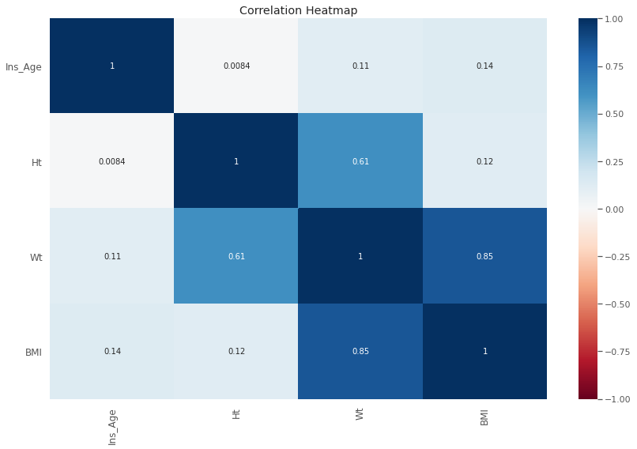

```python
df_misc.bp.plot_corr()
```

```
drive/My Drive/Colab Notebooks/Bhishan_Modules/bhishan/pandas_api.py:32: UserWarning:

registration of accessor <class 'bhishan.pandas_api.BPAccessor'> under name 'bp' for type <class 'pandas.core.frame.DataFrame'> is overriding a preexistingattribute with the same name.
```

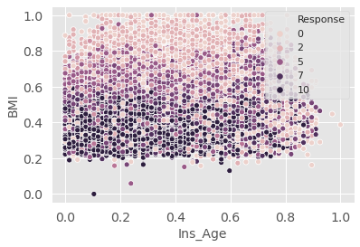

```python
sns.scatterplot(x = 'Ins_Age', y = 'BMI',hue=target,  data = df);
```

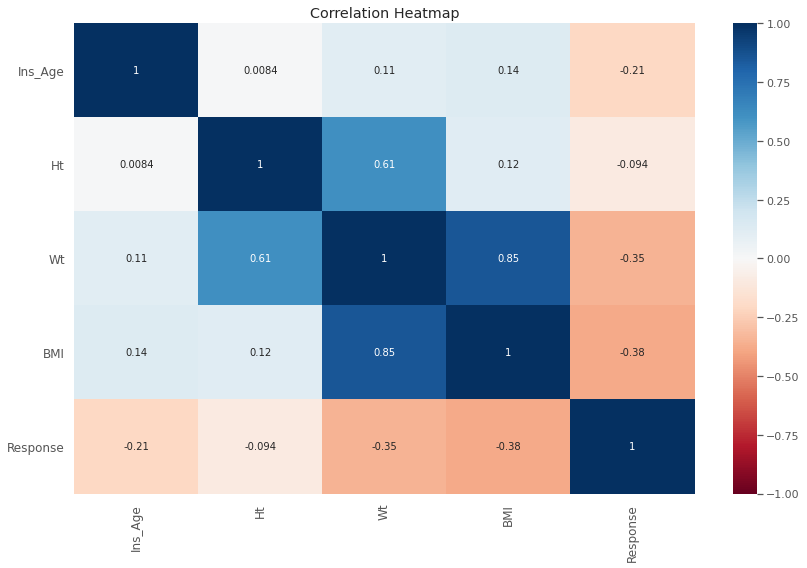

```python
df_misc.merge(df[target],left_index=True,right_index=True).bp.plot_corr()
```

## Product Features

```python
df_product = df[df.columns[df.columns.str.startswith('Product')]]
print(df_product.shape)
df_product.head()
```

```
(59381, 7)
```

|  | Product_Info_1 | Product_Info_2 | Product_Info_3 | Product_Info_4 | Product_Info_5 | Product_Info_6 | Product_Info_7 |
| --- | --- | --- | --- | --- | --- | --- | --- |
| 0 | 1 | D3 | 10 | 0.076923 | 2 | 1 | 1 |
| 1 | 1 | A1 | 26 | 0.076923 | 2 | 3 | 1 |
| 2 | 1 | E1 | 26 | 0.076923 | 2 | 3 | 1 |
| 3 | 1 | D4 | 10 | 0.487179 | 2 | 3 | 1 |
| 4 | 1 | D2 | 26 | 0.230769 | 2 | 3 | 1 |

```python
df_product.bp.get_column_descriptions(style=True)
```

|  | Feature | Type | Count | Unique | Missing | MissingPct | Zeros | ZerosPct |
| --- | --- | --- | --- | --- | --- | --- | --- | --- |
| 0 | Product_Info_4 | float64 | 59381 | 1491 | 0 | 0.0% | 1036 | 1.74% |
| 1 | Product_Info_1 | int64 | 59381 | 2 | 0 | 0.0% | 0 | 0.0% |
| 2 | Product_Info_2 | object | 59381 | 19 | 0 | 0.0% | 0 | 0.0% |
| 3 | Product_Info_3 | int64 | 59381 | 34 | 0 | 0.0% | 0 | 0.0% |
| 4 | Product_Info_5 | int64 | 59381 | 2 | 0 | 0.0% | 0 | 0.0% |
| 5 | Product_Info_6 | int64 | 59381 | 2 | 0 | 0.0% | 0 | 0.0% |
| 6 | Product_Info_7 | int64 | 59381 | 3 | 0 | 0.0% | 0 | 0.0% |

```python
df_product.bp.missing()
```

|  | Missing | Total | Percent |
| --- | --- | --- | --- |
| Product_Info_1 | 0 | 59,381 | 0.00% |
| Product_Info_2 | 0 | 59,381 | 0.00% |
| Product_Info_3 | 0 | 59,381 | 0.00% |
| Product_Info_4 | 0 | 59,381 | 0.00% |
| Product_Info_5 | 0 | 59,381 | 0.00% |
| Product_Info_6 | 0 | 59,381 | 0.00% |
| Product_Info_7 | 0 | 59,381 | 0.00% |

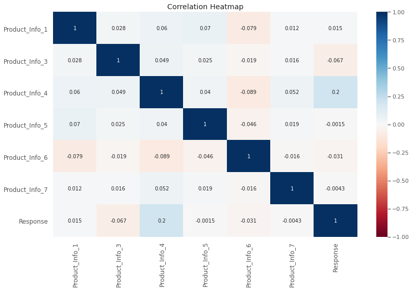

```python
df_product.merge(df[target],left_index=True,right_index=True).bp.plot_corr()
```

## Employment Features

```python
df_employement = df[df.columns[df.columns.str.startswith('Employment')]]
print(df_employement.shape)
df_employement.head()
```

```
(59381, 6)
```

|  | Employment_Info_1 | Employment_Info_2 | Employment_Info_3 | Employment_Info_4 | Employment_Info_5 | Employment_Info_6 |
| --- | --- | --- | --- | --- | --- | --- |
| 0 | 0.028 | 12 | 1 | 0.0 | 3 | NaN |
| 1 | 0.000 | 1 | 3 | 0.0 | 2 | 0.0018 |
| 2 | 0.030 | 9 | 1 | 0.0 | 2 | 0.0300 |
| 3 | 0.042 | 9 | 1 | 0.0 | 3 | 0.2000 |
| 4 | 0.027 | 9 | 1 | 0.0 | 2 | 0.0500 |

```python
df_employement.bp.get_column_descriptions()
```

|  | Feature | Type | Count | Unique | Missing | MissingPct | Zeros | ZerosPct |
| --- | --- | --- | --- | --- | --- | --- | --- | --- |
| 0 | Employment_Info_6 | float64 | 59381 | 992 | 10854 | 18.28% | 4042 | 6.81% |
| 1 | Employment_Info_4 | float64 | 59381 | 871 | 6779 | 11.42% | 44659 | 75.21% |
| 2 | Employment_Info_1 | float64 | 59381 | 1936 | 19 | 0.03% | 3688 | 6.21% |
| 3 | Employment_Info_2 | int64 | 59381 | 36 | 0 | 0.0% | 0 | 0.0% |
| 4 | Employment_Info_3 | int64 | 59381 | 2 | 0 | 0.0% | 0 | 0.0% |
| 5 | Employment_Info_5 | int64 | 59381 | 2 | 0 | 0.0% | 0 | 0.0% |

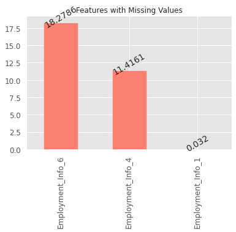

|  | Missing | Total | Percent |
| --- | --- | --- | --- |
| Employment_Info_6 | 10854 | 59,381 | 18.28% |
| Employment_Info_4 | 6779 | 59,381 | 11.42% |
| Employment_Info_1 | 19 | 59,381 | 0.03% |
| Employment_Info_2 | 0 | 59,381 | 0.00% |
| Employment_Info_3 | 0 | 59,381 | 0.00% |
| Employment_Info_5 | 0 | 59,381 | 0.00% |

```python
df_employement.bp.missing()
```

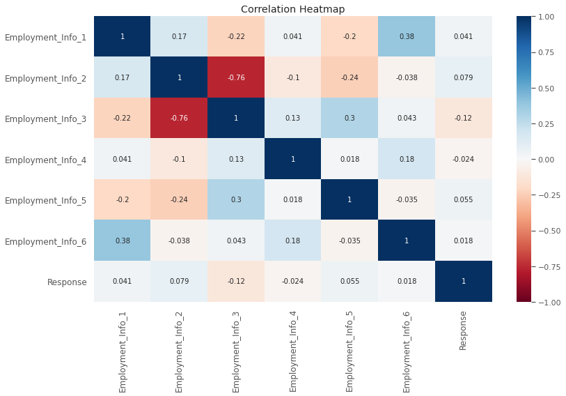

```python
df_employement.merge(df[target],left_index=True,right_index=True).bp.plot_corr()
```

## Insurance Features

```python
df_insurance = df[df.columns[df.columns.str.startswith('Insurance')]]
print(df_insurance.shape)
df_insurance.head()
```

```
(59381, 8)
```

|  | Insurance_History_1 | Insurance_History_2 | Insurance_History_3 | Insurance_History_4 | Insurance_History_5 | Insurance_History_7 | Insurance_History_8 | Insurance_History_9 |
| --- | --- | --- | --- | --- | --- | --- | --- | --- |
| 0 | 1 | 1 | 3 | 1 | 0.000667 | 1 | 1 | 2 |
| 1 | 2 | 1 | 3 | 1 | 0.000133 | 1 | 3 | 2 |
| 2 | 2 | 1 | 1 | 3 | NaN | 3 | 2 | 3 |
| 3 | 2 | 1 | 1 | 3 | NaN | 3 | 2 | 3 |
| 4 | 2 | 1 | 1 | 3 | NaN | 3 | 2 | 3 |

```python
df_insurance.bp.get_column_descriptions()
```

|  | Feature | Type | Count | Unique | Missing | MissingPct | Zeros | ZerosPct |
| --- | --- | --- | --- | --- | --- | --- | --- | --- |
| 0 | Insurance_History_5 | float64 | 59381 | 2265 | 25396 | 42.77% | 19 | 0.03% |
| 1 | Insurance_History_1 | int64 | 59381 | 2 | 0 | 0.0% | 0 | 0.0% |
| 2 | Insurance_History_2 | int64 | 59381 | 3 | 0 | 0.0% | 0 | 0.0% |
| 3 | Insurance_History_3 | int64 | 59381 | 3 | 0 | 0.0% | 0 | 0.0% |
| 4 | Insurance_History_4 | int64 | 59381 | 3 | 0 | 0.0% | 0 | 0.0% |
| 5 | Insurance_History_7 | int64 | 59381 | 3 | 0 | 0.0% | 0 | 0.0% |
| 6 | Insurance_History_8 | int64 | 59381 | 3 | 0 | 0.0% | 0 | 0.0% |
| 7 | Insurance_History_9 | int64 | 59381 | 3 | 0 | 0.0% | 0 | 0.0% |

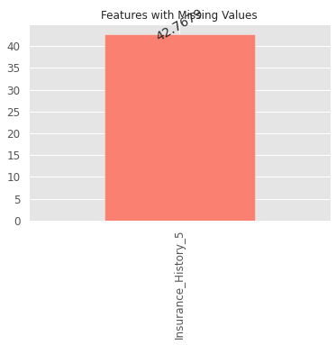

|  | Missing | Total | Percent |
| --- | --- | --- | --- |
| Insurance_History_5 | 25396 | 59,381 | 42.77% |
| Insurance_History_1 | 0 | 59,381 | 0.00% |
| Insurance_History_2 | 0 | 59,381 | 0.00% |
| Insurance_History_3 | 0 | 59,381 | 0.00% |
| Insurance_History_4 | 0 | 59,381 | 0.00% |
| Insurance_History_7 | 0 | 59,381 | 0.00% |
| Insurance_History_8 | 0 | 59,381 | 0.00% |
| Insurance_History_9 | 0 | 59,381 | 0.00% |

```python
df_insurance.bp.missing()
```

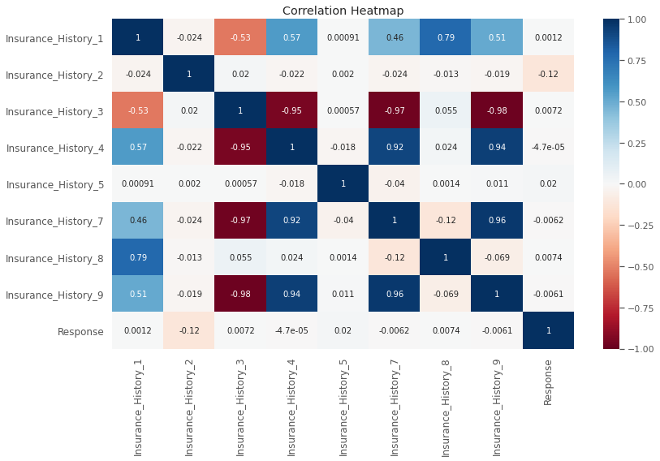

```python
df_insurance.merge(df[target],left_index=True,right_index=True).bp.plot_corr()
```

## Family Features

```python
df_family = df[df.columns[df.columns.str.startswith('Family')]]
print(df_family.shape)
df_family.head()
```

```
(59381, 5)
```

|  | Family_Hist_1 | Family_Hist_2 | Family_Hist_3 | Family_Hist_4 | Family_Hist_5 |
| --- | --- | --- | --- | --- | --- |
| 0 | 2 | NaN | 0.598039 | NaN | 0.526786 |
| 1 | 2 | 0.188406 | NaN | 0.084507 | NaN |
| 2 | 3 | 0.304348 | NaN | 0.225352 | NaN |
| 3 | 3 | 0.420290 | NaN | 0.352113 | NaN |
| 4 | 2 | 0.463768 | NaN | 0.408451 | NaN |

```python
df_family.bp.get_column_descriptions()
```

|  | Feature | Type | Count | Unique | Missing | MissingPct | Zeros | ZerosPct |
| --- | --- | --- | --- | --- | --- | --- | --- | --- |
| 0 | Family_Hist_5 | float64 | 59381 | 90 | 41811 | 70.41% | 3 | 0.01% |
| 1 | Family_Hist_3 | float64 | 59381 | 90 | 34241 | 57.66% | 4 | 0.01% |
| 2 | Family_Hist_2 | float64 | 59381 | 68 | 28656 | 48.26% | 1 | 0.0% |
| 3 | Family_Hist_4 | float64 | 59381 | 68 | 19184 | 32.31% | 9 | 0.02% |
| 4 | Family_Hist_1 | int64 | 59381 | 3 | 0 | 0.0% | 0 | 0.0% |

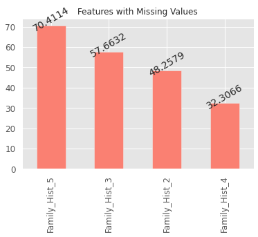

|  | Missing | Total | Percent |
| --- | --- | --- | --- |
| Family_Hist_5 | 41811 | 59,381 | 70.41% |
| Family_Hist_3 | 34241 | 59,381 | 57.66% |
| Family_Hist_2 | 28656 | 59,381 | 48.26% |
| Family_Hist_4 | 19184 | 59,381 | 32.31% |
| Family_Hist_1 | 0 | 59,381 | 0.00% |

```python
df_family.bp.missing()
```

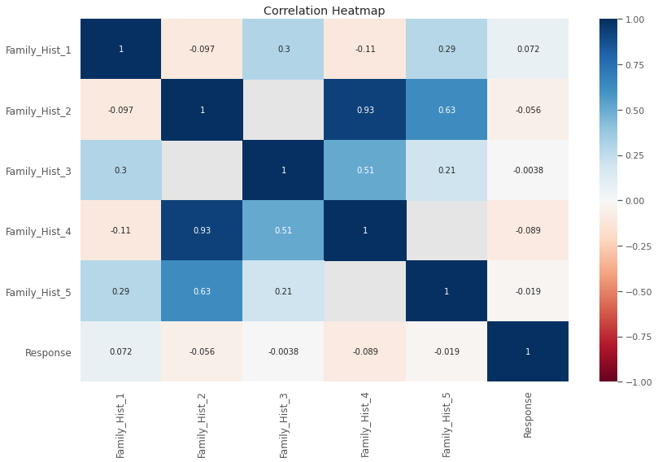

```python
df_family.merge(df[target],left_index=True,right_index=True).bp.plot_corr()
```

## Medical Features

```python
df_medical = df[df.columns[df.columns.str.startswith('Medical')]]
print(df_medical.shape)
df_medical.head()
```

```
(59381, 89)
```

|  | Medical_History_1 | Medical_History_2 | Medical_History_3 | Medical_History_4 | Medical_History_5 | Medical_History_6 | Medical_History_7 | Medical_History_8 | Medical_History_9 | Medical_History_10 | Medical_History_11 | Medical_History_12 | Medical_History_13 | Medical_History_14 | Medical_History_15 | Medical_History_16 | Medical_History_17 | Medical_History_18 | Medical_History_19 | Medical_History_20 | Medical_History_21 | Medical_History_22 | Medical_History_23 | Medical_History_24 | Medical_History_25 | Medical_History_26 | Medical_History_27 | Medical_History_28 | Medical_History_29 | … |
| --- | --- | --- | --- | --- | --- | --- | --- | --- | --- | --- | --- | --- | --- | --- | --- | --- | --- | --- | --- | --- | --- | --- | --- | --- | --- | --- | --- | --- | --- | --- |
| 0 | 4.0 | 112 | 2 | 1 | 1 | 3 | 2 | 2 | 1 | NaN | 3 | 2 | 3 | 3 | 240.0 | 3 | 3 | 1 | 1 | 2 | 1 | 2 | 3 | NaN | 1 | 3 | 3 | 1 | 3 | … |
| 1 | 5.0 | 412 | 2 | 1 | 1 | 3 | 2 | 2 | 1 | NaN | 3 | 2 | 3 | 3 | 0.0 | 1 | 3 | 1 | 1 | 2 | 1 | 2 | 3 | NaN | 1 | 3 | 3 | 1 | 3 | … |
| 2 | 10.0 | 3 | 2 | 2 | 1 | 3 | 2 | 2 | 2 | NaN | 3 | 2 | 3 | 3 | NaN | 1 | 3 | 1 | 1 | 2 | 1 | 2 | 3 | NaN | 2 | 2 | 3 | 1 | 3 | … |
| 3 | 0.0 | 350 | 2 | 2 | 1 | 3 | 2 | 2 | 2 | NaN | 3 | 2 | 3 | 3 | NaN | 1 | 3 | 1 | 1 | 2 | 2 | 2 | 3 | NaN | 1 | 3 | 3 | 1 | 3 | … |
| 4 | NaN | 162 | 2 | 2 | 1 | 3 | 2 | 2 | 2 | NaN | 3 | 2 | 3 | 3 | NaN | 1 | 3 | 1 | 1 | 2 | 1 | 2 | 3 | NaN | 2 | 2 | 3 | 1 | 3 | … |

```python
# df_medical.bp.get_column_descriptions()
```

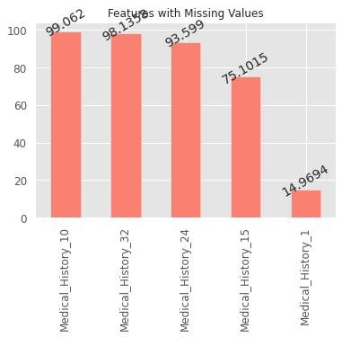

|  | Missing | Total | Percent |
| --- | --- | --- | --- |
| Medical_History_10 | 58824 | 59,381 | 99.06% |
| Medical_History_32 | 58274 | 59,381 | 98.14% |
| Medical_History_24 | 55580 | 59,381 | 93.60% |
| Medical_History_15 | 44596 | 59,381 | 75.10% |
| Medical_History_1 | 8889 | 59,381 | 14.97% |

```python
df_medical.bp.missing(clip_0=True)
```

```python
df_medical.merge(df[target],left_index=True,right_index=True).bp.plotly_corr(target)
```

[interactive chart not shown]

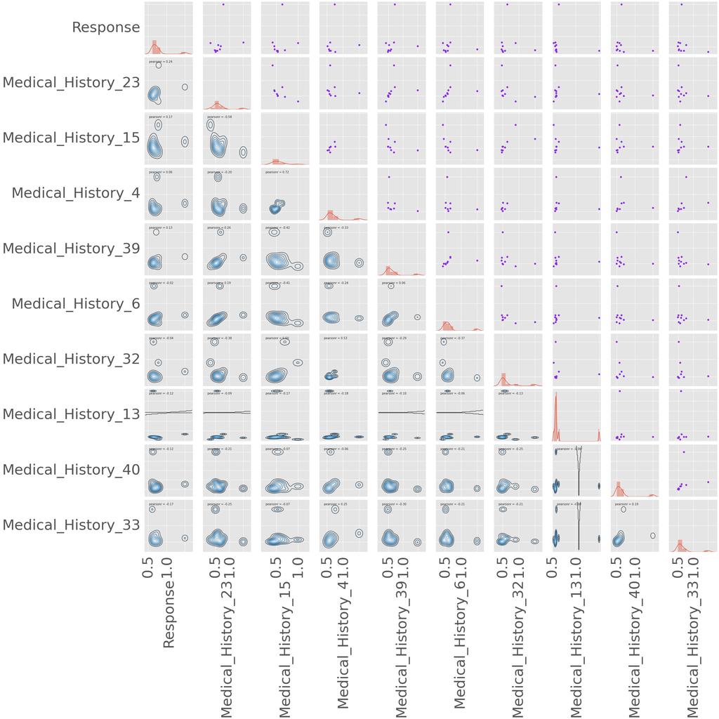

```python
df_medical.merge(df[target],left_index=True,right_index=True
                 ).bp.plot_corr_sns(target=target)
```

# Class Balance

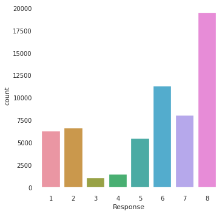

```python
sns.catplot(x='Response' , kind='count' , data=df)
```

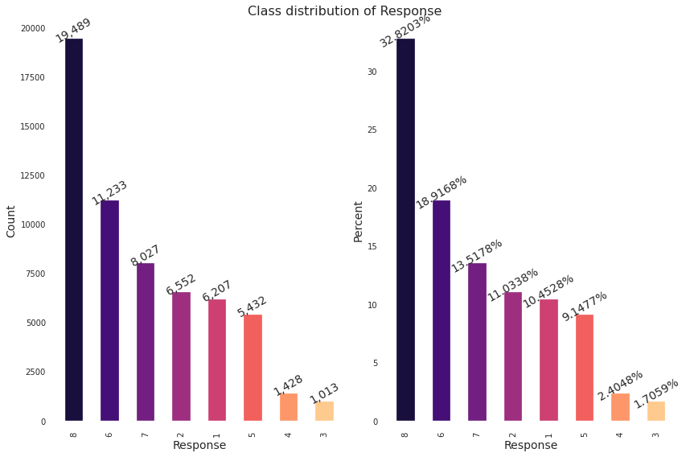

```python
df.bp.plot_cat('Response')
```

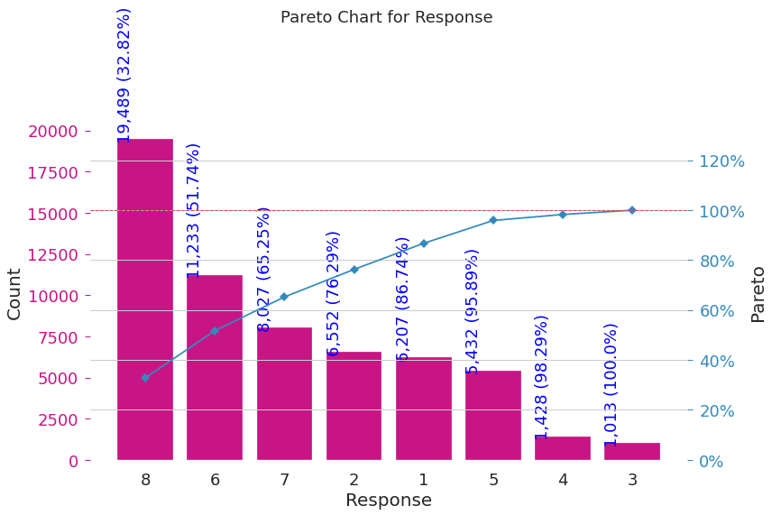

```python
df.bp.plot_pareto('Response')
```

# Dataframe Statistics Profiles

We can look at the overview of the data such as histogram, missing values, correlation, skewness using pandas_profiling module. Bear in mind that it may take long time to produce results. So saving them in a output file and only producing them once is a good way to go.

```python
import pandas_profiling
```

```python
out_dir = 'drive/My Drive/Colab Notebooks/outputs'
```

```python
out_dir = out_dir + '/Prudential/'
if not os.path.isdir(out_dir):
    os.makedirs(out_dir)

out_dir
```

```
'drive/My Drive/Colab Notebooks/outputs/Prudential/'
```

```python
df.head(2)
```

|  | Id | Product_Info_1 | Product_Info_2 | Product_Info_3 | Product_Info_4 | Product_Info_5 | Product_Info_6 | Product_Info_7 | Ins_Age | Ht | Wt | BMI | Employment_Info_1 | Employment_Info_2 | Employment_Info_3 | Employment_Info_4 | Employment_Info_5 | Employment_Info_6 | InsuredInfo_1 | InsuredInfo_2 | InsuredInfo_3 | InsuredInfo_4 | InsuredInfo_5 | InsuredInfo_6 | InsuredInfo_7 | Insurance_History_1 | Insurance_History_2 | Insurance_History_3 | Insurance_History_4 | … |
| --- | --- | --- | --- | --- | --- | --- | --- | --- | --- | --- | --- | --- | --- | --- | --- | --- | --- | --- | --- | --- | --- | --- | --- | --- | --- | --- | --- | --- | --- | --- |
| 0 | 2 | 1 | D3 | 10 | 0.076923 | 2 | 1 | 1 | 0.641791 | 0.581818 | 0.148536 | 0.323008 | 0.028 | 12 | 1 | 0.0 | 3 | NaN | 1 | 2 | 6 | 3 | 1 | 2 | 1 | 1 | 1 | 3 | 1 | … |
| 1 | 5 | 1 | A1 | 26 | 0.076923 | 2 | 3 | 1 | 0.059701 | 0.600000 | 0.131799 | 0.272288 | 0.000 | 1 | 3 | 0.0 | 2 | 0.0018 | 1 | 2 | 6 | 3 | 1 | 2 | 1 | 2 | 1 | 3 | 1 | … |

```python
# profile = df_misc.profile_report(html={'style': {'full_width':True}})
# profile.to_file(out_dir + 'df_profile.html')
```

```python
dfs = [df_misc, df_product, df_employement, df_insurance, df_medical]
ofiles = ['df_misc', 'df_product', 'df_employment','df_insurance', 'df_medical']
ofiles = [out_dir + i +'_profile.html' for i in ofiles]

ofiles[0]
```

```
'drive/My Drive/Colab Notebooks/outputs/Prudential/df_misc_profile.html'
```

```python
profile = df_misc.profile_report(html={'style': {'full_width':True}})
# profile
```

```python
profile = df_misc.profile_report(explorative=True)
profile
```

[interactive chart not shown]

```python
%%time
for dfx,ofile in zip(dfs,ofiles):
    dfx = dfx.merge(df[target],left_index=True,right_index=True)
    if not os.path.isfile(ofile):
         profile = dfx.profile_report(html={'style': {'full_width':True}})
         profile.to_file(ofile)
```

```
CPU times: user 66.1 ms, sys: 2.19 ms, total: 68.3 ms
Wall time: 70.3 ms
```